# **Semantic Segmentation of Aeriel Imagery from Hurricane Harvey**

by Houssam FOUKI - houssam.fouki@student-cs.fr

The actual project work was a **largely iterative process and trial of different model and techniques.** The below set of code is the final developed methodology and training.

- **Problem Statement −** The goal of this project is to de- sign and implement a deep learning model that can auto- matically segment images. The images in question were acquired by a small unmanned aerial vehicle (sUAV) in the city of Houston, Texas, and are being used to assess the damage to residential and public properties follow- ing the impact of Hurricane Harvey. The model will be required to segment the images into 26 distinct cate- gories, such as property roofs, swimming pools, vehicles, and grass. The overall objective is to accurately identify and classify different elements within the images to aid in the assessment of damage caused by Hurricane Har- vey. More concretely, the goal of this semantic image segmentation task is to label each pixel of an image with a corresponding class of what is being represented out of 26 possible categories. The expected output itself is an image. In order to tackle this task, we have focused on a very successful architecture, U-Net, which has proven to be performing well on similar image-segmentation tasks.*

```python
display(Image(url='https://user-images.githubusercontent.com/127489117/232487518-7f7fac2d-f231-4d30-b4fb-a2616b80f945.png'))
```

[figure not shown]

It has been observed during training that several training masks do not reflect the exact representation of an image, especially during the instance of a flooding. In the below example, we can see how a validation mask has not trees shown in a flooded region whereas the model predicted the exposed trees in the flooded area. This leads to the model outputting a lower accuracy even though it has technically produced the correct class. In future work, the dataset can be explored in detail to create a better image augmentation plan to integrate minority classes better and to deal with the situation of incorrect true masks.

```python
display(Image(url='https://user-images.githubusercontent.com/127489117/234980347-81522b3b-86d2-4b81-b10a-036101a3935a.png',  width=1300))
```

[figure not shown]

```python
import numpy as np
import pandas as pd
import torch.nn as nn
import matplotlib.pyplot as plt
import torch
from IPython.display import Image, display

from torch.utils.data import DataLoader, random_split #Load Data in dataloader and random split

import glob #For reading and storing path directories

from preprocessing import augment_images, patch_dataset #Import functions and classes defined in the attached preprocessing.py file
```

## Data Import and Visualization

```python
df_train = pd.read_csv('Data/train.csv')
df_train.head()
```

|  | Unnamed: 0 | image-id | image:01 | date:01 | type | geometry | label |
| --- | --- | --- | --- | --- | --- | --- | --- |
| 0 | 0 | 6373eb4cbfe85a8192f99b74 | gs://geoengine-dataset-houston-uav/rasters/719... | 2017-08-31T00:00:00+00:00 | polygon | 121 1709 105 1842 97 2070 383 2094 369 2580 10... | Property Roof |
| 1 | 1 | 6373eb4cbfe85a8192f99b74 | gs://geoengine-dataset-houston-uav/rasters/719... | 2017-08-31T00:00:00+00:00 | polygon | 2716 2336 2877 2527 2939 2504 2953 2460 2927 2... | Vehicle |
| 2 | 2 | 6373eb4cbfe85a8192f99b74 | gs://geoengine-dataset-houston-uav/rasters/719... | 2017-08-31T00:00:00+00:00 | polygon | 2809 2171 3002 2419 3099 2363 3044 2287 2962 2... | Vehicle |
| 3 | 3 | 6373eb4cbfe85a8192f99b74 | gs://geoengine-dataset-houston-uav/rasters/719... | 2017-08-31T00:00:00+00:00 | polygon | 3399 2922 3468 2918 3628 2952 3696 2894 3902 2... | Property Roof |
| 4 | 4 | 6373eb4cbfe85a8192f99b74 | gs://geoengine-dataset-houston-uav/rasters/719... | 2017-08-31T00:00:00+00:00 | polygon | 2826 1633 3063 1909 3136 1872 3245 1772 3047 1... | Secondary Structure |

```python
df_train.info()
```

```
<class 'pandas.core.frame.DataFrame'>
RangeIndex: 22419 entries, 0 to 22418
Data columns (total 7 columns):
 #   Column      Non-Null Count  Dtype
---  ------      --------------  -----
 0   Unnamed: 0  22419 non-null  int64
 1   image-id    22419 non-null  object
 2   image:01    22419 non-null  object
 3   date:01     22419 non-null  object
 4   type        22419 non-null  object
 5   geometry    22419 non-null  object
 6   label       22419 non-null  object
dtypes: int64(1), object(6)
memory usage: 1.2+ MB
```

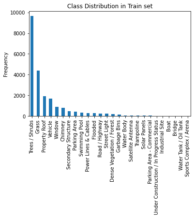

```python
#Train Data Label Distribution
df_train.label.value_counts().plot.bar()
plt.ylabel('Frequency')
plt.title('Class Distribution in Train set')
plt.show()
```

## Data Pre-processing

Images shall all augmented at random using brightening/darkening, horizontal/vertical flips and rotation techniques. Since the images are quite large, images shall be splits into smaller patches so that the model can capture model details. These shall be stored in a dataset object which would slow training since the augmented images are only split into a patch when called in the object. However, it saves the need to save the patches locally on the drive.

```python
#Create a new Training Images based on conditions set in augment_image function found in preprocessing.py
path = 'Data/'
train_img_path, train_msk_path = augment_images(image_path = path + 'sample_images/',
                                                mask_path = path + 'sample_masks/', parent_dir = path)
```

```python
#Create Train Dataset object using patch_dataset class defined in preprocessing.py
train_dataset = patch_dataset(sorted(glob.glob(train_img_path + '/*')),
                              sorted(glob.glob(train_msk_path+'/*')),patch_size_x = 1333, patch_size_y = 1500)
```

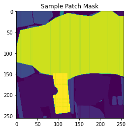

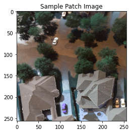

```python
#Example mask patch
rand_idx = np.random.randint(len(glob.glob(train_img_path + '/*')) - 1, dtype=int)
rand_patch_idx = np.random.randint(train_dataset[0][1].shape[0] - 1, dtype=int)
plt.figure()
plt.imshow(train_dataset[rand_idx][1][rand_patch_idx])
plt.title('Sample Patch Mask')
plt.show()
plt.figure()

plt.imshow(train_dataset[rand_idx][0][rand_patch_idx].permute(1,2,0).detach().numpy())
plt.title('Sample Patch Image')
plt.show()
```

## Model Training

The baseline architecture for this projects is a U-NET model who's architecture has been built has been built from scratch and can be found in the old files in the repository. For the final model trials, pre-trained U-NET and PSP-NET were used to boost performance.

```python
!pip install -q -U segmentation-models-pytorch albumentations > /dev/null
import segmentation_models_pytorch as smp # semantic segmentation library with pre-trained segmentation models
from torch.optim import lr_scheduler #learning rate schedules that decays learning rate during training
```

```python
train_size = int(0.8 * len(train_dataset))
test_size = len(train_dataset) - train_size
train_set, test_set = random_split(train_dataset, [train_size, test_size])
```

```python
#small batch size chosen since each entry in a batch contains 6 patches. So each batch will contained 60 images to train on
train_dataloader = DataLoader(train_set, batch_size=10, shuffle=True)
val_dataloader = DataLoader(test_set, batch_size=10, shuffle=False)
```

```python
device = torch.device('cuda' if torch.cuda.is_available() else 'cpu')
print(f'Device used: {device}')
```

```
Device used: cpu
```

```python
from models import train_smp_model #function to train unet models from the models.py
from plot_utils import plot_losses #function to plot losses from plot_utils.py
```

### U-NET Training

```python
model_Unet = smp.Unet(
    encoder_name = 'resnet101',
    encoder_weights = 'imagenet',
    in_channels = 3,
    classes = 27,
    decoder_channels=(512, 256, 128, 64, 32),
    activation = None,
).to(device)
```

```python
lr = 0.001 #initial learning rate
optimizer = torch.optim.Adam(model_Unet.parameters(), lr = lr)
epochs = 30
lr_scheduler = lr_scheduler.PolynomialLR(optimizer,total_iters= epochs, power=0.9) #schedule to decay initial learning rate
```

```python
from models import train_smp_model #function created to train U-Net
from plot_utils import plot_losses #function creates to plot training losses
```

```python
model_Unet,total_train_losses, total_train_accuracy, total_train_f1, total_val_losses, total_val_accuracy, total_val_f1 = train_smp_model(model_Unet,
                                                                                                                                     optimizer,
                                                                                                                                     epochs,
                                                                                                                                     train_dataloader,
                                                                                                                                     val_dataloader,
                                                                                                                                     lr_scheduler,
                                                                                                                                     device,
                                                                                                                                     model_name = 'Unet')
```

```
TRAIN       Epoch: 1 | Epoch metrics | loss: 2.3886, f1: 0.209, accuracy: 0.374
```

```
VAL       Epoch: 1 | Epoch metrics | loss: 2.5305, f1: 0.192, accuracy: 0.402
```

```
TRAIN       Epoch: 2 | Epoch metrics | loss: 1.4795, f1: 0.320, accuracy: 0.585
```

```
VAL       Epoch: 2 | Epoch metrics | loss: 2.0386, f1: 0.294, accuracy: 0.551
```

```
TRAIN       Epoch: 3 | Epoch metrics | loss: 1.2536, f1: 0.338, accuracy: 0.619
```

```
VAL       Epoch: 3 | Epoch metrics | loss: 1.3336, f1: 0.319, accuracy: 0.596
```

```
TRAIN       Epoch: 4 | Epoch metrics | loss: 1.1915, f1: 0.335, accuracy: 0.638
```

```
VAL       Epoch: 4 | Epoch metrics | loss: 1.3983, f1: 0.307, accuracy: 0.598
```

```
TRAIN       Epoch: 5 | Epoch metrics | loss: 1.1188, f1: 0.353, accuracy: 0.651
```

```
VAL       Epoch: 5 | Epoch metrics | loss: 1.2107, f1: 0.340, accuracy: 0.629
```

```
TRAIN       Epoch: 6 | Epoch metrics | loss: 1.1076, f1: 0.355, accuracy: 0.656
```

```
VAL       Epoch: 6 | Epoch metrics | loss: 1.0899, f1: 0.366, accuracy: 0.671
```

```
TRAIN       Epoch: 7 | Epoch metrics | loss: 1.0656, f1: 0.362, accuracy: 0.666
```

```
VAL       Epoch: 7 | Epoch metrics | loss: 1.1763, f1: 0.345, accuracy: 0.651
```

```
TRAIN       Epoch: 8 | Epoch metrics | loss: 1.0505, f1: 0.364, accuracy: 0.670
```

```
VAL       Epoch: 8 | Epoch metrics | loss: 1.0849, f1: 0.368, accuracy: 0.692
```

```
TRAIN       Epoch: 9 | Epoch metrics | loss: 0.9727, f1: 0.374, accuracy: 0.700
```

```
VAL       Epoch: 9 | Epoch metrics | loss: 1.0426, f1: 0.364, accuracy: 0.688
```

```
TRAIN       Epoch: 10 | Epoch metrics | loss: 0.9595, f1: 0.370, accuracy: 0.702
```

```
VAL       Epoch: 10 | Epoch metrics | loss: 1.1687, f1: 0.346, accuracy: 0.680
```

```
TRAIN       Epoch: 11 | Epoch metrics | loss: 0.9461, f1: 0.372, accuracy: 0.695
```

```
VAL       Epoch: 11 | Epoch metrics | loss: 1.0306, f1: 0.366, accuracy: 0.685
```

```
TRAIN       Epoch: 12 | Epoch metrics | loss: 0.9427, f1: 0.378, accuracy: 0.706
```

```
VAL       Epoch: 12 | Epoch metrics | loss: 1.0991, f1: 0.360, accuracy: 0.672
```

```
TRAIN       Epoch: 13 | Epoch metrics | loss: 0.9204, f1: 0.380, accuracy: 0.714
```

```
VAL       Epoch: 13 | Epoch metrics | loss: 1.0319, f1: 0.373, accuracy: 0.699
```

```
TRAIN       Epoch: 14 | Epoch metrics | loss: 0.9055, f1: 0.382, accuracy: 0.718
```

```
VAL       Epoch: 14 | Epoch metrics | loss: 0.9426, f1: 0.367, accuracy: 0.717
```

```
TRAIN       Epoch: 15 | Epoch metrics | loss: 0.8558, f1: 0.385, accuracy: 0.731
```

```
VAL       Epoch: 15 | Epoch metrics | loss: 0.9677, f1: 0.371, accuracy: 0.711
```

```
TRAIN       Epoch: 16 | Epoch metrics | loss: 0.8143, f1: 0.390, accuracy: 0.746
```

```
VAL       Epoch: 16 | Epoch metrics | loss: 0.9895, f1: 0.376, accuracy: 0.712
```

```
TRAIN       Epoch: 17 | Epoch metrics | loss: 0.8195, f1: 0.389, accuracy: 0.748
```

```
VAL       Epoch: 17 | Epoch metrics | loss: 0.9298, f1: 0.367, accuracy: 0.725
```

```
TRAIN       Epoch: 18 | Epoch metrics | loss: 0.7880, f1: 0.396, accuracy: 0.758
```

```
VAL       Epoch: 18 | Epoch metrics | loss: 0.9633, f1: 0.380, accuracy: 0.723
```

```
TRAIN       Epoch: 19 | Epoch metrics | loss: 0.7898, f1: 0.395, accuracy: 0.754
```

```
VAL       Epoch: 19 | Epoch metrics | loss: 0.9894, f1: 0.361, accuracy: 0.705
```

```
TRAIN       Epoch: 20 | Epoch metrics | loss: 0.7531, f1: 0.401, accuracy: 0.765
```

```
VAL       Epoch: 20 | Epoch metrics | loss: 0.9773, f1: 0.359, accuracy: 0.701
```

```
TRAIN       Epoch: 21 | Epoch metrics | loss: 0.7235, f1: 0.403, accuracy: 0.779
```

```
VAL       Epoch: 21 | Epoch metrics | loss: 0.9819, f1: 0.373, accuracy: 0.699
```

```
TRAIN       Epoch: 22 | Epoch metrics | loss: 0.6899, f1: 0.409, accuracy: 0.791
```

```
VAL       Epoch: 22 | Epoch metrics | loss: 0.8561, f1: 0.390, accuracy: 0.749
```

```
TRAIN       Epoch: 23 | Epoch metrics | loss: 0.6608, f1: 0.412, accuracy: 0.803
```

```
VAL       Epoch: 23 | Epoch metrics | loss: 0.8517, f1: 0.388, accuracy: 0.747
```

```
TRAIN       Epoch: 24 | Epoch metrics | loss: 0.6432, f1: 0.417, accuracy: 0.806
```

```
VAL       Epoch: 24 | Epoch metrics | loss: 0.9103, f1: 0.385, accuracy: 0.725
```

```
TRAIN       Epoch: 25 | Epoch metrics | loss: 0.6389, f1: 0.416, accuracy: 0.811
```

```
VAL       Epoch: 25 | Epoch metrics | loss: 0.8720, f1: 0.393, accuracy: 0.754
```

```
TRAIN       Epoch: 26 | Epoch metrics | loss: 0.6208, f1: 0.420, accuracy: 0.818
```

```
VAL       Epoch: 26 | Epoch metrics | loss: 1.1135, f1: 0.387, accuracy: 0.736
```

```
TRAIN       Epoch: 27 | Epoch metrics | loss: 0.5987, f1: 0.422, accuracy: 0.824
```

```
VAL       Epoch: 27 | Epoch metrics | loss: 0.8872, f1: 0.388, accuracy: 0.743
```

```
TRAIN       Epoch: 28 | Epoch metrics | loss: 0.5694, f1: 0.427, accuracy: 0.834
```

```
VAL       Epoch: 28 | Epoch metrics | loss: 0.8422, f1: 0.391, accuracy: 0.748
```

```
TRAIN       Epoch: 29 | Epoch metrics | loss: 0.5450, f1: 0.432, accuracy: 0.843
```

```
VAL       Epoch: 29 | Epoch metrics | loss: 0.8239, f1: 0.395, accuracy: 0.760
```

```
TRAIN       Epoch: 30 | Epoch metrics | loss: 0.5062, f1: 0.437, accuracy: 0.855
```

```
VAL       Epoch: 30 | Epoch metrics | loss: 0.8563, f1: 0.393, accuracy: 0.753
```

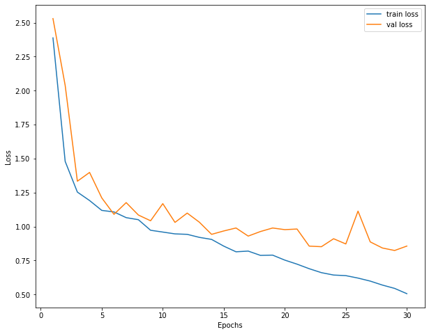

```python
plot_losses(total_train_losses, total_val_losses)
```

### PSP-NET Training

```python
##PSP-net initialized with 101-deep residual network encoder, pre-trained imagenet weights, 3 input channels
#27 output channels
model_PSP = smp.PSPNet(
    encoder_name = 'resnet101',
    encoder_weights = 'imagenet',
    classes = 27,
    activation = None,
).to(device)
```

```python
min_val_f1 = 0.350 #baseline
```

```python
lr = 0.001 #initial learning rate
optimizer = torch.optim.Adam(model_PSP.parameters(), lr = lr)
epochs = 30
lr_scheduler = lr_scheduler.PolynomialLR(optimizer,total_iters= epochs, power=0.9) #schedule to decay initial learning rate
```

```python
from models import train_smp_model #function created to train U-Net
from plot_utils import plot_losses #function creates to plot training losses
```

```python
model_PSP,total_train_losses, total_train_accuracy, total_train_f1, total_val_losses, total_val_accuracy, total_val_f1 = train_smp_model(model_PSP,
                                                                                                                                     optimizer,
                                                                                                                                     epochs,
                                                                                                                                     train_dataloader,
                                                                                                                                     val_dataloader,
                                                                                                                                     lr_scheduler,
                                                                                                                                     device,
                                                                                                                                     model_name = 'PSP')
```

```
  warnings.warn(
```

```
TRAIN       Epoch: 1 | Epoch metrics | loss: 1.5943, f1: 0.247, accuracy: 0.535
```

```
VAL       Epoch: 1 | Epoch metrics | loss: 1.3306, f1: 0.289, accuracy: 0.569
```

```
TRAIN       Epoch: 2 | Epoch metrics | loss: 1.2586, f1: 0.296, accuracy: 0.610
```

```
VAL       Epoch: 2 | Epoch metrics | loss: 1.2519, f1: 0.298, accuracy: 0.601
```

```
TRAIN       Epoch: 3 | Epoch metrics | loss: 1.1027, f1: 0.320, accuracy: 0.650
```

```
VAL       Epoch: 3 | Epoch metrics | loss: 1.2514, f1: 0.320, accuracy: 0.632
```

```
TRAIN       Epoch: 4 | Epoch metrics | loss: 1.0803, f1: 0.322, accuracy: 0.655
```

```
VAL       Epoch: 4 | Epoch metrics | loss: 1.0352, f1: 0.350, accuracy: 0.671
```

```
TRAIN       Epoch: 5 | Epoch metrics | loss: 0.9790, f1: 0.333, accuracy: 0.690
```

```
VAL       Epoch: 5 | Epoch metrics | loss: 1.3263, f1: 0.342, accuracy: 0.646
```

```
TRAIN       Epoch: 6 | Epoch metrics | loss: 0.9429, f1: 0.342, accuracy: 0.697
```

```
VAL       Epoch: 6 | Epoch metrics | loss: 1.0557, f1: 0.358, accuracy: 0.682
```

```
TRAIN       Epoch: 7 | Epoch metrics | loss: 0.8893, f1: 0.346, accuracy: 0.711
```

```
VAL       Epoch: 7 | Epoch metrics | loss: 1.0003, f1: 0.349, accuracy: 0.664
```

```
TRAIN       Epoch: 8 | Epoch metrics | loss: 0.8410, f1: 0.350, accuracy: 0.722
```

```
VAL       Epoch: 8 | Epoch metrics | loss: 1.0283, f1: 0.353, accuracy: 0.688
```

```
TRAIN       Epoch: 9 | Epoch metrics | loss: 0.8219, f1: 0.355, accuracy: 0.729
```

```
VAL       Epoch: 9 | Epoch metrics | loss: 0.8332, f1: 0.362, accuracy: 0.724
```

```
TRAIN       Epoch: 10 | Epoch metrics | loss: 0.7859, f1: 0.361, accuracy: 0.741
```

```
VAL       Epoch: 10 | Epoch metrics | loss: 0.9938, f1: 0.365, accuracy: 0.697
```

```
TRAIN       Epoch: 11 | Epoch metrics | loss: 0.7720, f1: 0.359, accuracy: 0.743
```

```
VAL       Epoch: 11 | Epoch metrics | loss: 0.9229, f1: 0.346, accuracy: 0.712
```

```
TRAIN       Epoch: 12 | Epoch metrics | loss: 0.7369, f1: 0.366, accuracy: 0.755
```

```
VAL       Epoch: 12 | Epoch metrics | loss: 0.7929, f1: 0.382, accuracy: 0.746
```

```
TRAIN       Epoch: 13 | Epoch metrics | loss: 0.7257, f1: 0.371, accuracy: 0.760
```

```
VAL       Epoch: 13 | Epoch metrics | loss: 0.8017, f1: 0.379, accuracy: 0.743
```

```
TRAIN       Epoch: 14 | Epoch metrics | loss: 0.6910, f1: 0.374, accuracy: 0.769
```

```
VAL       Epoch: 14 | Epoch metrics | loss: 0.7493, f1: 0.392, accuracy: 0.764
```

```
TRAIN       Epoch: 15 | Epoch metrics | loss: 0.6680, f1: 0.378, accuracy: 0.777
```

```
VAL       Epoch: 15 | Epoch metrics | loss: 0.7013, f1: 0.393, accuracy: 0.771
```

```
TRAIN       Epoch: 16 | Epoch metrics | loss: 0.6503, f1: 0.382, accuracy: 0.783
```

```
VAL       Epoch: 16 | Epoch metrics | loss: 0.7750, f1: 0.361, accuracy: 0.754
```

```
TRAIN       Epoch: 17 | Epoch metrics | loss: 0.6443, f1: 0.381, accuracy: 0.785
```

```
VAL       Epoch: 17 | Epoch metrics | loss: 0.7324, f1: 0.382, accuracy: 0.764
```

```
TRAIN       Epoch: 18 | Epoch metrics | loss: 0.6245, f1: 0.386, accuracy: 0.792
```

```
VAL       Epoch: 18 | Epoch metrics | loss: 0.7725, f1: 0.386, accuracy: 0.759
```

```
TRAIN       Epoch: 19 | Epoch metrics | loss: 0.6025, f1: 0.388, accuracy: 0.801
```

```
VAL       Epoch: 19 | Epoch metrics | loss: 0.6704, f1: 0.394, accuracy: 0.781
```

```
TRAIN       Epoch: 20 | Epoch metrics | loss: 0.5946, f1: 0.389, accuracy: 0.801
```

```
VAL       Epoch: 20 | Epoch metrics | loss: 0.6946, f1: 0.395, accuracy: 0.782
```

```
TRAIN       Epoch: 21 | Epoch metrics | loss: 0.5721, f1: 0.394, accuracy: 0.811
```

```
VAL       Epoch: 21 | Epoch metrics | loss: 0.6496, f1: 0.394, accuracy: 0.784
```

```
TRAIN       Epoch: 22 | Epoch metrics | loss: 0.5485, f1: 0.397, accuracy: 0.818
```

```
VAL       Epoch: 22 | Epoch metrics | loss: 0.6833, f1: 0.406, accuracy: 0.784
```

```
TRAIN       Epoch: 23 | Epoch metrics | loss: 0.5539, f1: 0.396, accuracy: 0.814
```

```
VAL       Epoch: 23 | Epoch metrics | loss: 0.6419, f1: 0.411, accuracy: 0.793
```

```
TRAIN       Epoch: 24 | Epoch metrics | loss: 0.5107, f1: 0.403, accuracy: 0.830
```

```
VAL       Epoch: 24 | Epoch metrics | loss: 0.6269, f1: 0.408, accuracy: 0.799
```

```
TRAIN       Epoch: 25 | Epoch metrics | loss: 0.4890, f1: 0.408, accuracy: 0.841
```

```
VAL       Epoch: 25 | Epoch metrics | loss: 0.6267, f1: 0.406, accuracy: 0.799
```

```
TRAIN       Epoch: 26 | Epoch metrics | loss: 0.4812, f1: 0.409, accuracy: 0.840
```

```
VAL       Epoch: 26 | Epoch metrics | loss: 0.6135, f1: 0.411, accuracy: 0.804
```

```
TRAIN       Epoch: 27 | Epoch metrics | loss: 0.4700, f1: 0.410, accuracy: 0.846
```

```
VAL       Epoch: 27 | Epoch metrics | loss: 0.5915, f1: 0.416, accuracy: 0.812
```

```
TRAIN       Epoch: 28 | Epoch metrics | loss: 0.4491, f1: 0.415, accuracy: 0.853
```

```
VAL       Epoch: 28 | Epoch metrics | loss: 0.6088, f1: 0.414, accuracy: 0.806
```

```
TRAIN       Epoch: 29 | Epoch metrics | loss: 0.4375, f1: 0.417, accuracy: 0.858
```

```
VAL       Epoch: 29 | Epoch metrics | loss: 0.5816, f1: 0.420, accuracy: 0.817
```

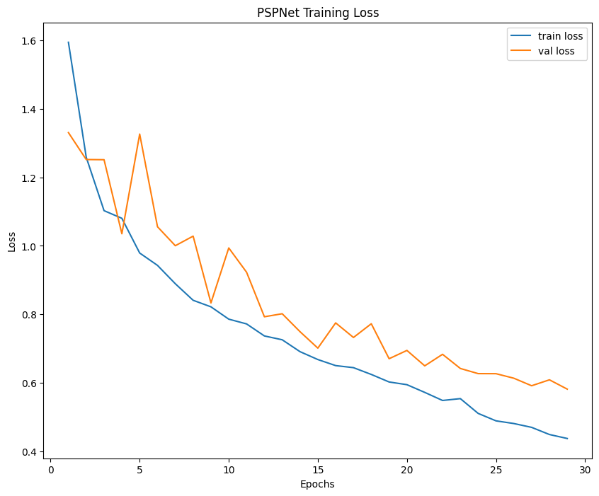

```python
plot_losses(total_train_losses, total_val_losses)
```

## Sample Model Outputs

Since PSP-Net outperformed the U-Net model, it was used as out final model for submissions. Below are some of the sample predictive outputs from the model on the validation set.

```python
from plot_utils import make_pred, plot_predictions #imported from plot_utils
```

```python
model_PSP = smp.PSPNet(
    encoder_name = 'resnet101',
    encoder_weights = 'imagenet',
    classes = 27,
    activation = None,
).to(device)

model_PSP.load_state_dict(torch.load(f'Models/PSP_pat_mid_29.pt',map_location = device))
```

```python
path_images = sorted(glob.glob('Data/sample_images/*')) #Path to validation set images
path_masks = sorted(glob.glob('Data/sample_masks/*')) #Path to training masks
```

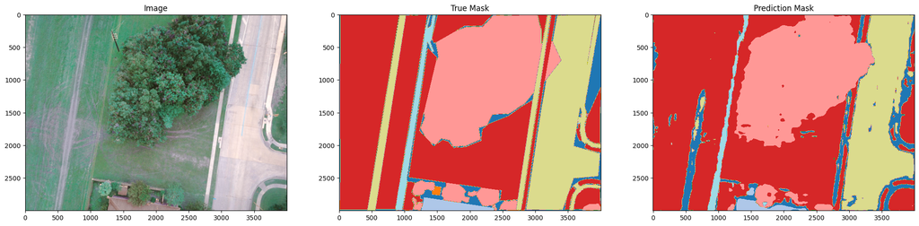

```python
image_num = 0
image, mask, pred = make_pred(model_PSP, path_images, path_masks, image_num)
plot_predictions(image, mask, pred)
```

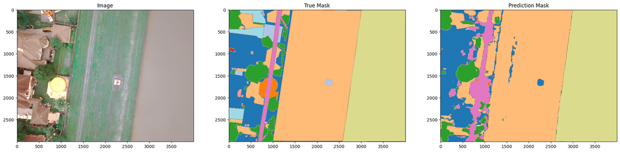

```python
image_num = 1
image, mask, pred = make_pred(model_PSP, path_images, path_masks, image_num)
plot_predictions(image, mask, pred)
```

It can be observed that the model struggles with the finer and small details in the observations. We can see however that the models successfully captures the important aspects and can detect that there is not flooding. Below is a similar example.

**Example with Flooding:**

Again, it can be observed that the model struggles with fine details. However, one interesting featur highlighted in this picture is there is also a flaw in the training set which could have impacted the training of the models. We can see that the true mask shows the entire area flooding when in reality there are trees exposed in the flooding area (captured by the prediction mask). Hence, the model outputted technically a correct prediction but one that is not accurate when compared to the mask. **It is therefore crucial for future work to first disect through the image set and to find masks that could negatively impact training.**

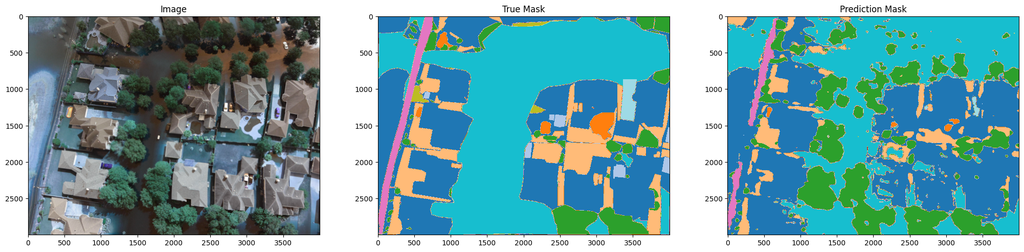

```python
image_num = 2
image, mask, pred = make_pred(model_PSP, path_images, path_masks, image_num)
plot_predictions(image, mask, pred)
```